# slr_mlr_1

Alberto Tomasin

# Esercizio 1

I dati in `grains.dat` sono stati raccolti nel 2007 in uno studio sula relazione tra la resa in termini di alcool nel processo di distillazione e l’azoto contenuto nel grano distillato. I dati sono stati raccolti in quattro diverse aree del Regno Unito. Il dataset ha tre colonne: **nitrogen** è la percentuale di azoto (per kilogrammo), **alcohol** è la resa in alcool in Litri per Tonnellata, **elocation** indica il luogo in cui è stato coltivato il grano.

```r
grain_df <- read.csv('data/grains.dat', sep = ' ', header = TRUE)
head(grain_df)
```

```
##   nitrogen  alcohol  location
## 1 1.605882 439.0909 E.Lothian
## 2 1.627731 441.1364 E.Lothian
## 3 1.647899 448.0682 E.Lothian
## 4 1.689916 450.1136 E.Lothian
## 5 1.689916 447.1591 E.Lothian
## 6 1.688235 437.1591 E.Lothian
```

1. Si produca un grafico dei dati. La relazione tra le variabili in esame appare lineare?

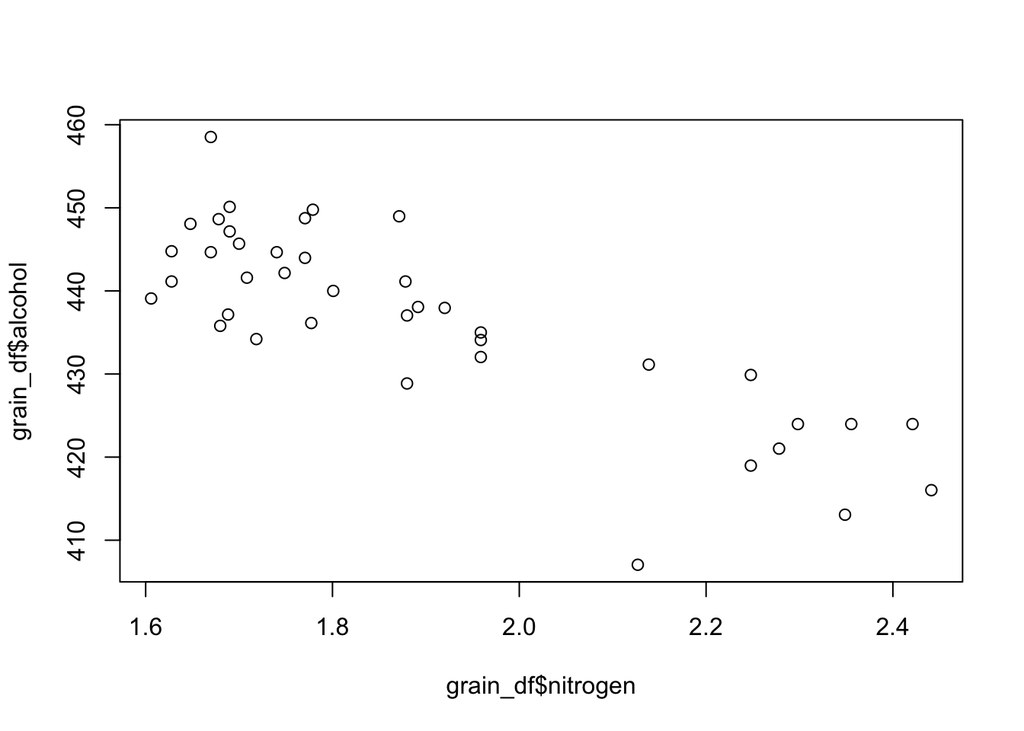

```r
plot(grain_df$alcohol ~ grain_df$nitrogen)
```

La relazione appare lineare, con una tendenza a decrescere, in particolare possiamo affermare che all’aumentare della concentrazione di azoto, il grado alcolico diminuisce.

2. Si dia una stima puntuale per $\alpha$ e $\beta$.

Per calcolare la stima puntuale di $\alpha$ e $\beta$ posso usare le formule:
$$\beta = \frac{\sum_{i=1}^n (x_i - \bar x)(y_i - \bar y)}{\sum_{i=1}^n
(x_i - \bar x)^2}$$

$$\alpha = \bar y -\beta \bar x$$

basate sul principio dei minimi quadrati, che tenta di minimizzare la somma dei quadrati degli errori.

Possiamo calcolare la stessa stima usando R

```r
fit1 <- lm(alcohol ~ nitrogen, data = grain_df)
coef(fit1)
```

```
## (Intercept)    nitrogen
##   506.87058   -37.03356
```

3. Si dia una stima intervallare ad un livello di confidenza di 99% per $\alpha$ e $\beta$.

```r
confint(fit1, level = .99)
```

```
##                 0.5 %    99.5 %
## (Intercept) 485.61483 528.12633
## nitrogen    -48.14073 -25.92639
```

4. Quali sono le assunzioni necessarie per poter aver stime puntuali per i valori $\alpha$ e $\beta$? Quali sono le assunzioni necessarie per poter ottenere delle stime intervallari per $\alpha$ e $\beta$?

Le assunzioni necessarie per poter avere stime puntuali e stime intervallari per $\alpha$ e $\beta$ sono le assunzioni relative ai modelli lineari: linearità, indipendenza dagli errori, normalità degli errori, omoschedasticità.

**linearità**

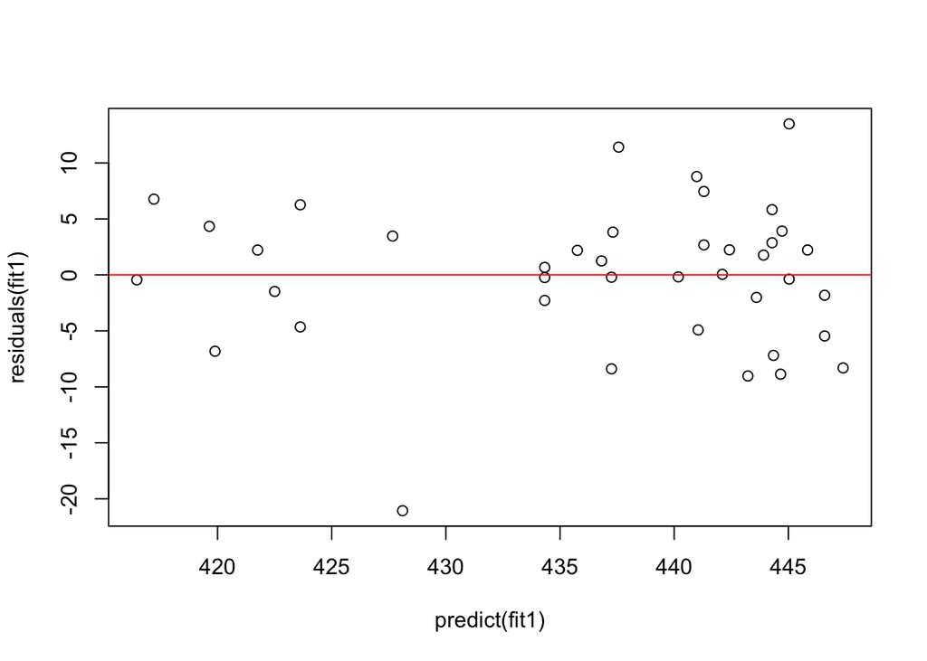

```r
plot(predict(fit1), residuals(fit1))
abline(h = 0, col = 'red')
```

L’assunzione di linearità è verificata nel momento in cui i punti si distribuiscono casualmente attorno allo zero.

**indipendenza degli errori**

tramite un grafico dei residui siamo in grado di verificare l’indipendenza degli errori

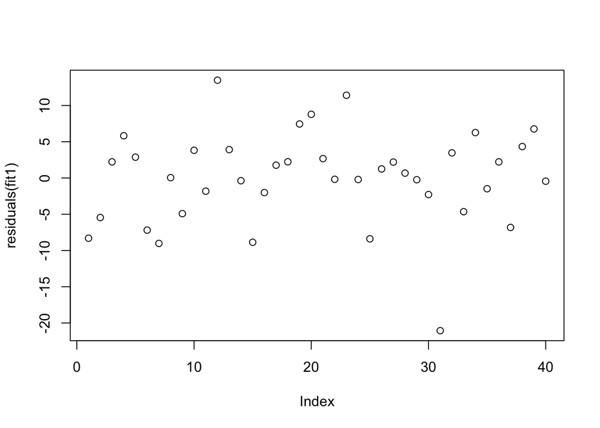

```r
plot(residuals(fit1))
```

Notiamo che non viene seguito alcun pattern, l’assunzione di indipendenza risulta verificata

**normalità dei residui**

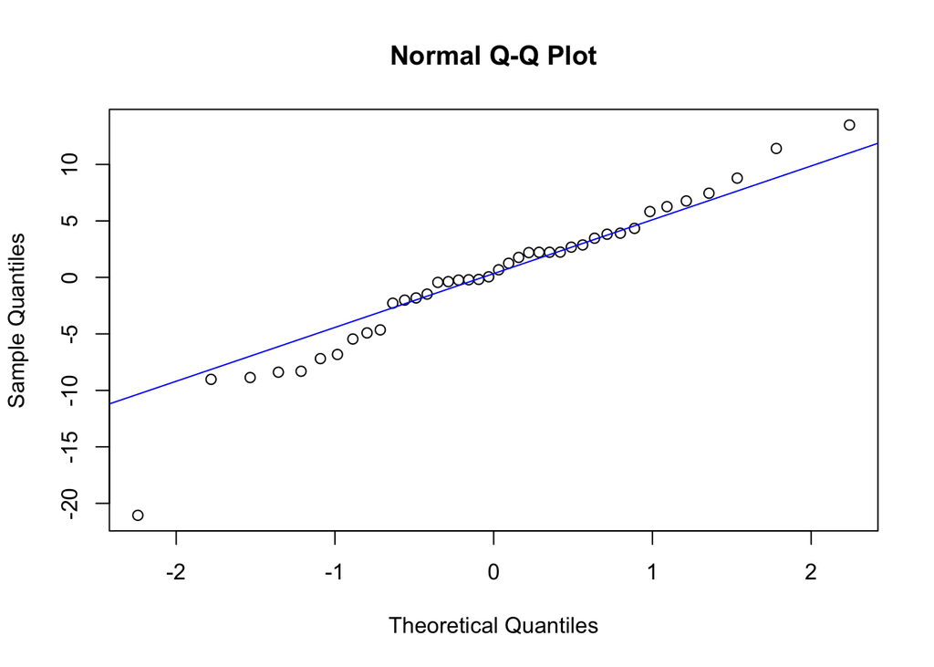

```r
qqnorm(residuals(fit1))
qqline(residuals(fit1), col = 'blue')
```

I punti sono disposti attorno alla retta ad indicare una buona normalità dei residui. L’assunzione di normalità è verificata.

**omoschedasticità**

possiamo anche in questo caso usare il grafico valori predetti vs errori per verificare l’assuzione di omoschedasticità

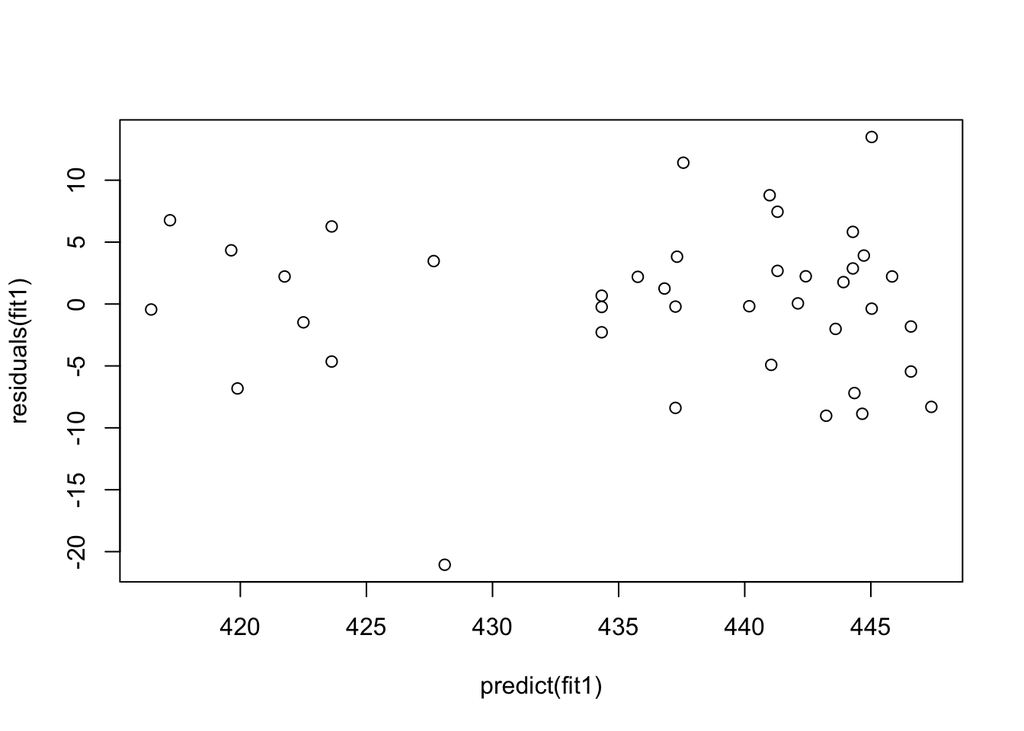

```r
plot(predict(fit1), residuals(fit1))
```